# exploratory_data_finding slides

## Project: Data Exploration of the performance of globally-selected 15/16-year-old students in Mathematics, Reading and Science Literacy, based on the results of the PISA 2012 test

### **by Eshan Kulkarni**

## Introduction of the topic and dataset

### Introduction to PISA *(ref.: NCES 2014-024, U.S. Department of Education)*

#### What Is PISA?

The Program for International Student Assessment (PISA) is a system of international assessments that allows countries to compare outcomes of learning as students near the end of compulsory schooling. PISA core assessments measure the performance of 15-year-old students in mathematics, science, and reading literacy every 3 years. Coordinated by the Organization for Economic Cooperation and Development (OECD), PISA was first implemented in 2000 in 32 countries. It has since grown to 65 education systems in 2012.

#### What PISA Measures

PISA’s goal is to assess students’ preparation for the challenges of life as young adults. PISA assesses the application of knowledge in mathematics, science, and reading literacy to problems within a reallife context (OECD 1999). PISA does not focus explicitly on curricular outcomes and uses the term “literacy” in each subject area to indicate its broad focus on the application of knowledge and skills.

Each PISA data collection cycle assesses one of the three core subject areas in depth (considered the major subject area), although all three core subjects are assessed in each cycle (the other two subjects are considered minor subject areas for that assessment year). Assessing all three subjects every 3 years allows countries to have a consistent source of achievement data in each of the three subjects, while rotating one area as the primary focus over the years. Mathematics was the major subject area in 2012, as it was in 2003, since each subject is a major subject area once every three cycles. In 2012, mathematics, science, and reading literacy were assessed primarily through a paper-and-pencil assessment, and problem solving was administered via a computer-based assessment. In addition to these core assessments, education systems could participate in optional paper-based financial literacy and computer-based mathematics and reading assessments.

### Introduction to the PISA 2012 dataset

PISA is a survey of students' skills and knowledge as they approach the end of compulsory education. It is not a conventional school test. Rather than examining how well students have learned the school curriculum, it looks at how well prepared they are for life beyond school.

Around 510,000 students in 65 economies took part in the PISA 2012 assessment of reading, mathematics and science representing about 28 million 15-year-olds globally. Of those economies, 44 took part in an assessment of creative problem solving and 18 in an assessment of financial literacy.

# Univariant Analysis & Visualization

### Math, Science, Reading Score Distribution across Students

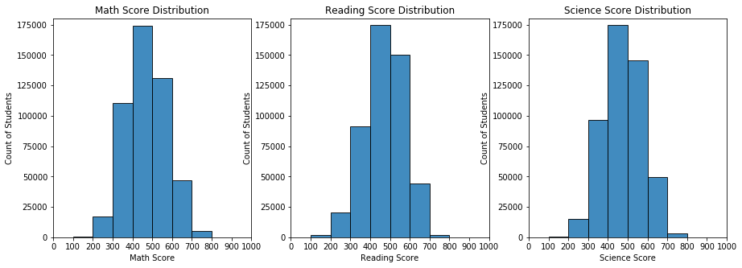

```python
plt.figure(figsize=[15, 5])
hist_bins = np.arange(0, 1000 + 1, 100)

# math score
plt.subplot(1, 3, 1);
plt.hist(df['Math Score'], bins=hist_bins, ec = 'black', alpha = 0.85);

plt.xlim(0, 1000);
plt.xticks(hist_bins)
plt.ylim(0, 180000 + 1);
plt.xlabel('Math Score');
plt.ylabel('Count of Students');
plt.title("Math Score Distribution");

# reading score
plt.subplot(1, 3, 2);
plt.hist(df['Reading Score'], bins=hist_bins, ec = 'black', alpha = 0.85);

plt.xlim(0, 1000);
plt.xticks(hist_bins)
plt.ylim(0, 180000 + 1);
plt.xlabel('Reading Score');
plt.ylabel('Count of Students');
plt.title("Reading Score Distribution");

# science score
plt.subplot(1, 3, 3);
plt.hist(df['Science Score'], bins=hist_bins, ec = 'black', alpha = 0.85);

plt.xlim(0, 1000);
plt.xticks(hist_bins)
plt.ylim(0, 180000 + 1);
plt.xlabel('Science Score');
plt.ylabel('Count of Students');
plt.title("Science Score Distribution");
```

For the above distribution, most of the student scores are in the range of 400-500 points

Majority of student score points are from 300-600 points

### Gender Distribution Across Students

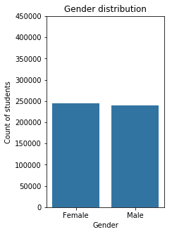

```python
plt.figure(figsize=[3, 5]);
sns.countplot(x = 'Gender', data = df, color = sns.color_palette()[0]);

y_ticks = np.arange(0, 450000 + 1, 50000)
plt.yticks(y_ticks, y_ticks);
plt.ylabel("Count of students");
plt.title('Gender distribution');
```

The Gender ratio in the Dataset is almost equally distributed

### Countries having 'Exceptionally Performing' Students

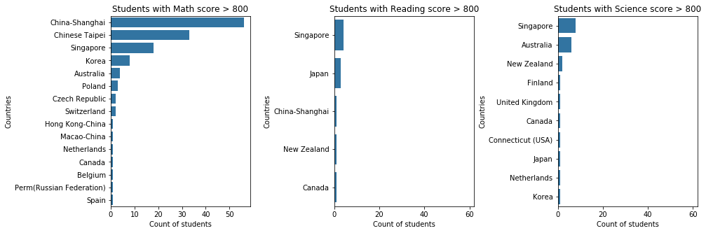

```python
plt.figure(figsize = [15, 5])
plt.subplots_adjust(wspace = 0.6)
x_lim_max = math_score.values[0] + 6

plt.subplot(1, 3, 1)
sns.barplot(y = math_score.index, x = math_score.values, color = sns.color_palette()[0])
plt.title('Students with Math score > 800');
plt.xlabel('Count of students');
plt.ylabel('Countries');

plt.subplot(1, 3, 2)
sns.barplot(y = reading_score.index, x = reading_score.values, color = sns.color_palette()[0])
plt.xlim(0, x_lim_max);
plt.title('Students with Reading score > 800');
plt.xlabel('Count of students');
plt.ylabel('Countries');

plt.subplot(1, 3, 3)
sns.barplot(y = science_score.index, x = science_score.values, color = sns.color_palette()[0])
plt.xlim(0, x_lim_max);
plt.title('Students with Science score > 800');
plt.xlabel('Count of students');
plt.ylabel('Countries');
```

China-Shanghai have the most students who have expectinally high math score

Singapore has the most students who have expectinally high reading & sciece score

### Count of Parents with Same Culture Background

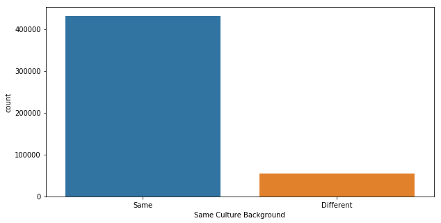

```python
plt.figure(figsize=(10, 5))
sns.countplot(x='Same Culture Background', data=df);
plt.show();
```

Parent with Same Culture Background are significantly more than parent with different culture background

# Bivariant Analysis & Visualization

### Gender wise - Score Distribution

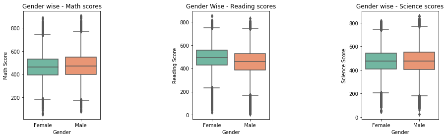

```python
plt.figure(figsize = [15, 4])
plt.subplots_adjust(wspace = 1.2)

plt.subplot(1, 3, 1)
sns.boxplot(x = df['Gender'], y = df['Math Score'], palette = 'Set2')
plt.title('Gender wise - Math scores');

plt.subplot(1, 3, 2)
sns.boxplot(x = df['Gender'], y = df['Reading Score'], palette = 'Set2')
plt.title('Gender Wise - Reading scores');

plt.subplot(1, 3, 3)
sns.boxplot(x = df['Gender'], y = df['Science Score'], palette = 'Set2');
plt.title('Gender wise - Science scores');
```

It can be seen that Male student perform slightly better than Female students in Math

It can be seen that Female student perform slightly better than Male students in Reading

It can be seen that Male student & female students performance is same in Science

### Students scoring above 800, Country wise.

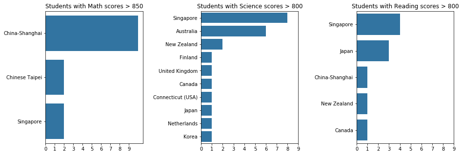

```python
math_score = df[(df['Math Score'] >= 850)]['Country'].value_counts()
science_score = df[(df['Science Score'] >= 800)]['Country'].value_counts()
reading_score = df[(df['Reading Score'] >= 800)]['Country'].value_counts()

plt.figure(figsize = [15, 5])
plt.subplots_adjust(wspace = 0.6)
x_lim_max = science_score.values[0]

plt.subplot(1, 3, 1)
sns.barplot(y = math_score.index, x = math_score.values, color = sns.color_palette()[0])
plt.title('Students with Math scores > 850');
plt.xticks(np.arange(0, x_lim_max + 2, 1));

plt.subplot(1, 3, 2)
sns.barplot(y = science_score.index, x = science_score.values, color = sns.color_palette()[0])
plt.title('Students with Science scores > 800');
plt.xticks(np.arange(0, x_lim_max + 2, 1));

plt.subplot(1, 3, 3)
sns.barplot(y = reading_score.index, x = reading_score.values, color = sns.color_palette()[0])
plt.title('Students with Reading scores > 800');
plt.xticks(np.arange(0, x_lim_max + 2, 1));
```

China-Shanghai have more students score more than 850 in Math

Singapore have more students score more than 800 in Science & Reading

### Distribution of scores according to Culture Background

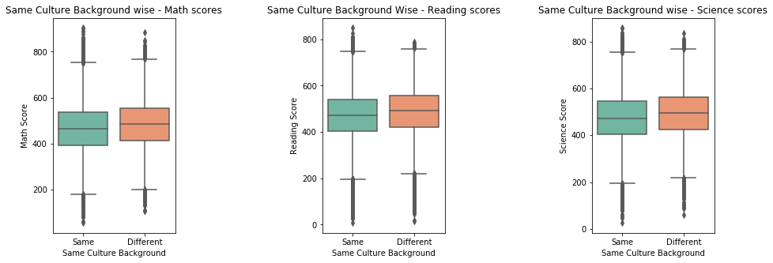

```python
plt.figure(figsize = [15, 5])
plt.subplots_adjust(wspace = 1.2)

plt.subplot(1, 3, 1)
sns.boxplot(x = df['Same Culture Background'], y = df['Math Score'], palette = 'Set2')
plt.title('Same Culture Background wise - Math scores');

plt.subplot(1, 3, 2)
sns.boxplot(x = df['Same Culture Background'], y = df['Reading Score'], palette = 'Set2')
plt.title('Same Culture Background Wise - Reading scores');

plt.subplot(1, 3, 3)
sns.boxplot(x = df['Same Culture Background'], y = df['Science Score'], palette = 'Set2');
plt.title('Same Culture Background wise - Science scores');
```

It can be seen that, students coming from heterogenic family backgrounds report increased performance in all areas, compared to students from homogenous family backgrounds.

# Multivariant Analysis & Visualization

### Pair-by-pair representation of different scores

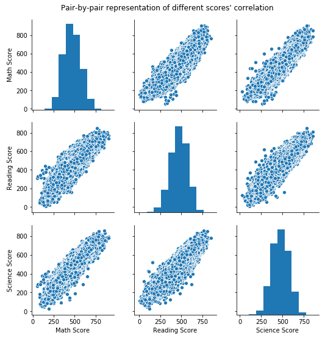

```python
grid = sns.pairplot(data = df, vars=["Math Score", "Reading Score", "Science Score"]);
grid.fig.suptitle("Pair-by-pair representation of different scores' correlation", y = 1.02);
```

There is a very strong and positive correlation between any pair of the three variables representing the scores of the three subjects.